# Homework2

Shraddha Hemant Kadam (sxk190069@utdallas.edu)

06/23/2020

**Loading Packages**

```r
pacman::p_load(data.table, forecast, leaps, tidyverse, ggcorrplot, corrplot, MASS)
theme_set(theme_classic())
```

**Using Airfares data set**

```r
air.df <- read.csv("Airfares.csv")

# Remove first four features
air.df <- air.df[-c(1:4)]
head(air.df)
```

```
##   COUPON NEW VACATION  SW      HI S_INCOME E_INCOME   S_POP   E_POP       SLOT
## 1   1.00   3       No Yes 5291.99    28637    21112 3036732  205711       Free
## 2   1.06   3       No  No 5419.16    26993    29838 3532657 7145897       Free
## 3   1.06   3       No  No 9185.28    30124    29838 5787293 7145897       Free
## 4   1.06   3       No Yes 2657.35    29260    29838 7830332 7145897 Controlled
## 5   1.06   3       No Yes 2657.35    29260    29838 7830332 7145897       Free
## 6   1.01   3       No Yes 3408.11    26046    29838 2230955 7145897       Free
##   GATE DISTANCE   PAX   FARE
## 1 Free      312  7864  64.11
## 2 Free      576  8820 174.47
## 3 Free      364  6452 207.76
## 4 Free      612 25144  85.47
## 5 Free      612 25144  85.47
## 6 Free      309 13386  56.76
```

**Question 1** **Correlation table and scatterplots:**

```r
#correlation table
numeric.air.df <- air.df[, -c(3,4,10,11)]
round(cor(numeric.air.df),3)
```

```
##          COUPON    NEW     HI S_INCOME E_INCOME  S_POP  E_POP DISTANCE    PAX
## COUPON    1.000  0.020 -0.347   -0.088    0.047 -0.108  0.095    0.747 -0.337
## NEW       0.020  1.000  0.054    0.027    0.113 -0.017  0.059    0.081  0.010
## HI       -0.347  0.054  1.000   -0.027    0.082 -0.172 -0.062   -0.312 -0.169
## S_INCOME -0.088  0.027 -0.027    1.000   -0.139  0.517 -0.272    0.028  0.138
## E_INCOME  0.047  0.113  0.082   -0.139    1.000 -0.144  0.458    0.177  0.260
## S_POP    -0.108 -0.017 -0.172    0.517   -0.144  1.000 -0.280    0.018  0.285
## E_POP     0.095  0.059 -0.062   -0.272    0.458 -0.280  1.000    0.116  0.315
## DISTANCE  0.747  0.081 -0.312    0.028    0.177  0.018  0.116    1.000 -0.102
## PAX      -0.337  0.010 -0.169    0.138    0.260  0.285  0.315   -0.102  1.000
## FARE      0.497  0.092  0.025    0.209    0.326  0.145  0.285    0.670 -0.091
##            FARE
## COUPON    0.497
## NEW       0.092
## HI        0.025
## S_INCOME  0.209
## E_INCOME  0.326
## S_POP     0.145
## E_POP     0.285
## DISTANCE  0.670
## PAX      -0.091
## FARE      1.000
```

```r
head(numeric.air.df)
```

```
##   COUPON NEW      HI S_INCOME E_INCOME   S_POP   E_POP DISTANCE   PAX   FARE
## 1   1.00   3 5291.99    28637    21112 3036732  205711      312  7864  64.11
## 2   1.06   3 5419.16    26993    29838 3532657 7145897      576  8820 174.47
## 3   1.06   3 9185.28    30124    29838 5787293 7145897      364  6452 207.76
## 4   1.06   3 2657.35    29260    29838 7830332 7145897      612 25144  85.47
## 5   1.06   3 2657.35    29260    29838 7830332 7145897      612 25144  85.47
## 6   1.01   3 3408.11    26046    29838 2230955 7145897      309 13386  56.76
```

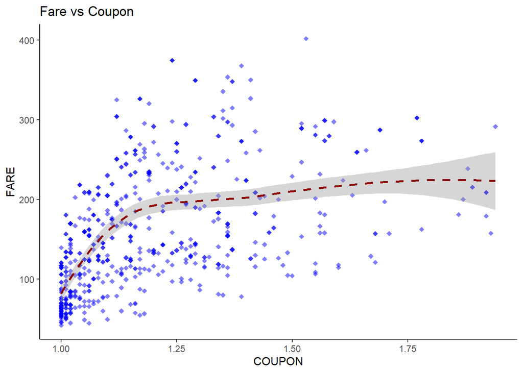

```r
#scatter plot
ggplot(air.df, aes(x = COUPON, y = FARE)) +
  geom_point(size= 2, shape= 18, color = "blue", alpha = 0.5) +
  ggtitle("Fare vs Coupon")+
  geom_smooth(linetype="dashed",
             color="darkred")
```

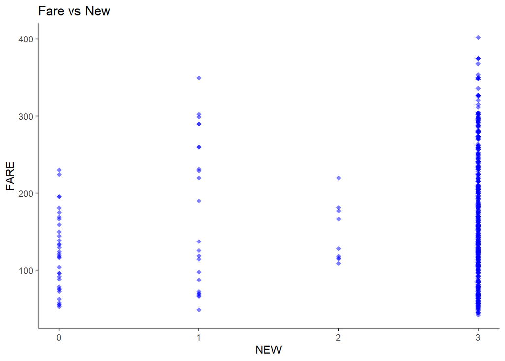

```r
ggplot(air.df, aes(x = NEW, y = FARE)) +
  geom_point(size= 2, shape= 18, color = "blue", alpha = 0.5) +
  ggtitle("Fare vs New")+
  geom_smooth(linetype="dashed",
             color="darkred")
```

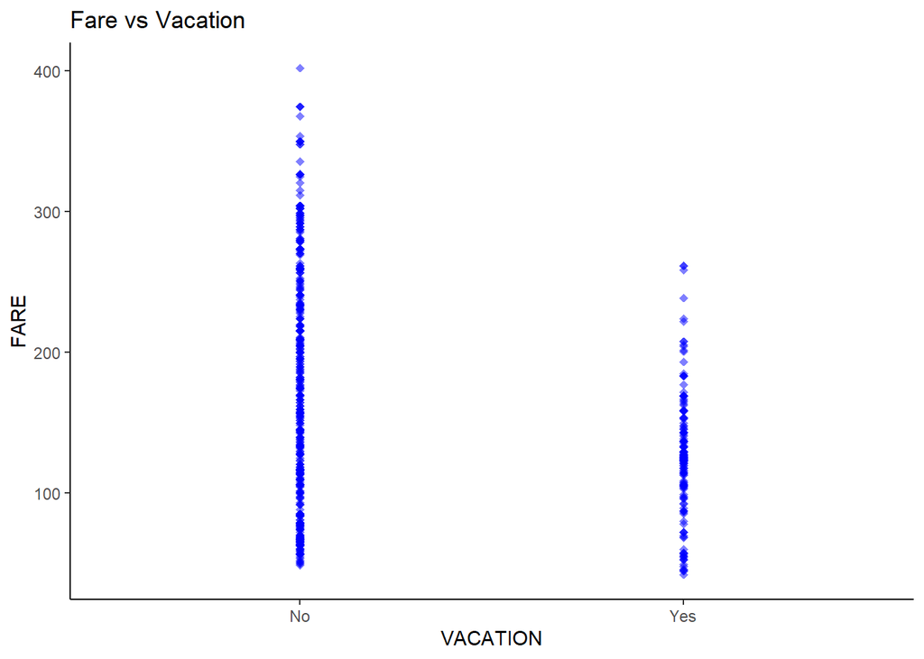

```r
ggplot(air.df, aes(x = VACATION, y = FARE)) +
  geom_point(size= 2, shape= 18, color = "blue", alpha = 0.5) +
  ggtitle("Fare vs Vacation")+
  geom_smooth(linetype="dashed",
             color="darkred")
```

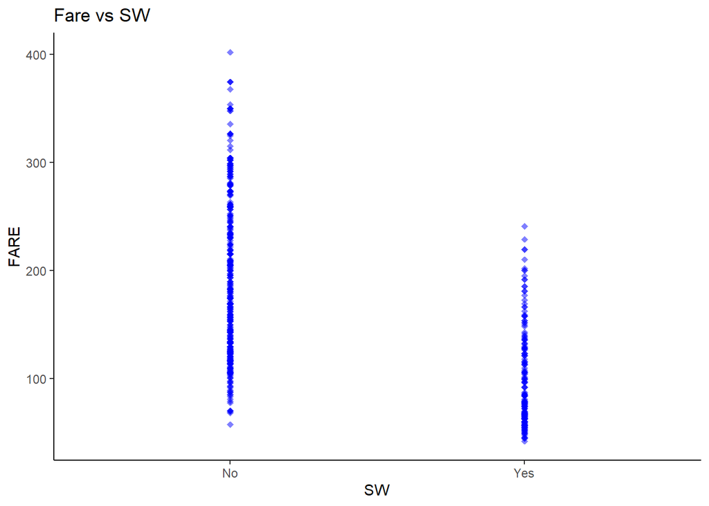

```r
ggplot(air.df, aes(x = SW, y = FARE)) +
  geom_point(size= 2, shape= 18, color = "blue", alpha = 0.5) +
  ggtitle("Fare vs SW")+
  geom_smooth(linetype="dashed",
             color="darkred")
```

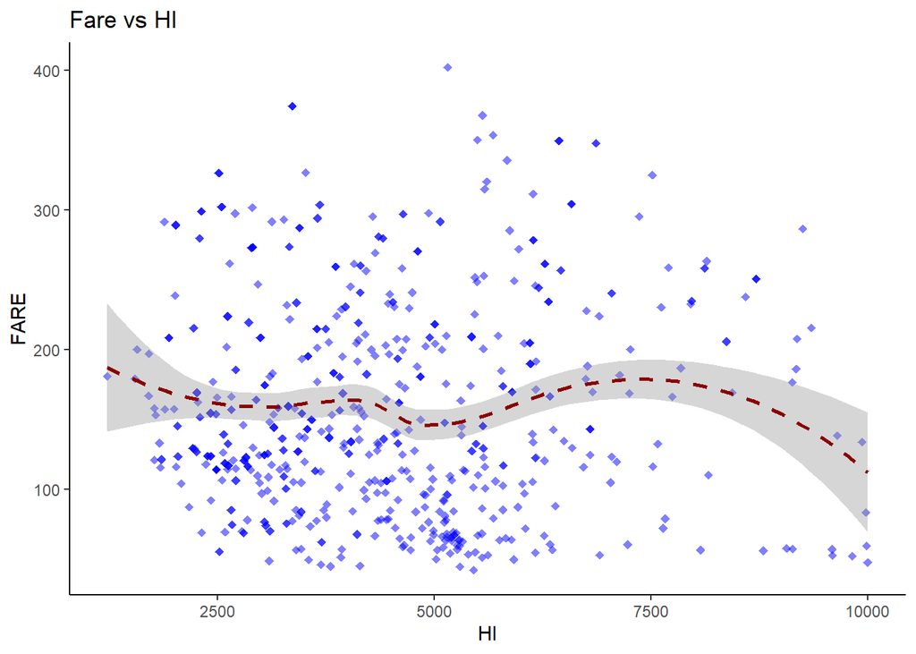

```r
ggplot(air.df, aes(x = HI, y = FARE)) +
  geom_point(size= 2, shape= 18, color = "blue", alpha = 0.5) +
  ggtitle("Fare vs HI")+
  geom_smooth(linetype="dashed",
             color="darkred")
```

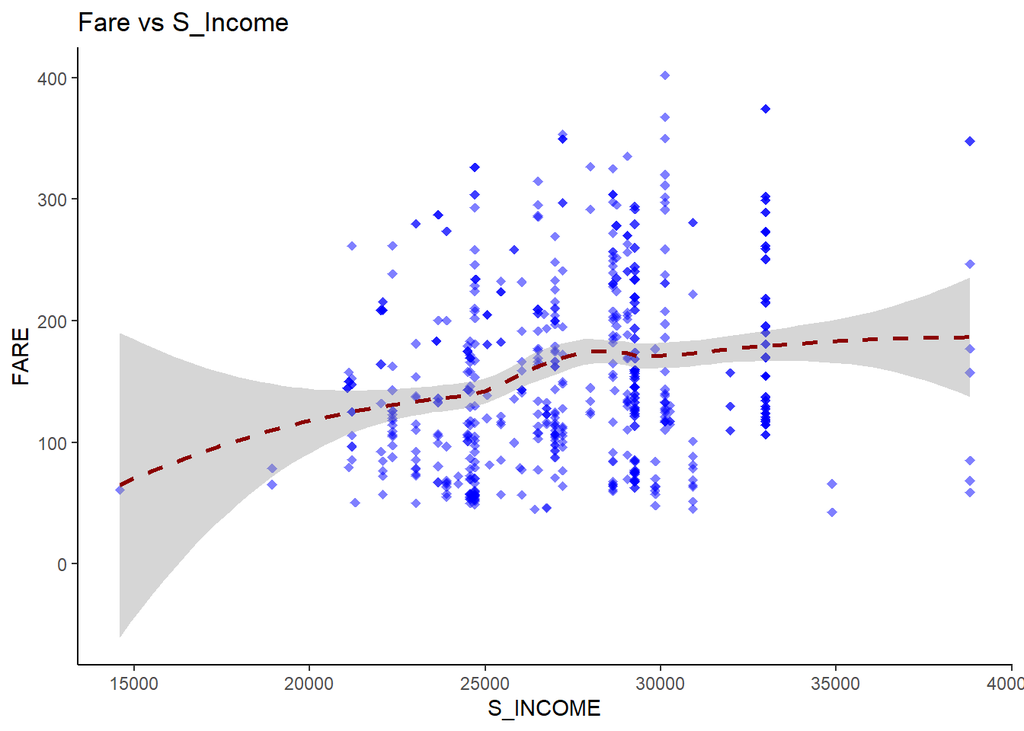

```r
ggplot(air.df, aes(x = S_INCOME, y = FARE)) +
  geom_point(size= 2, shape= 18, color = "blue", alpha = 0.5) +
  ggtitle("Fare vs S_Income")+
  geom_smooth(linetype="dashed",
             color="darkred")
```

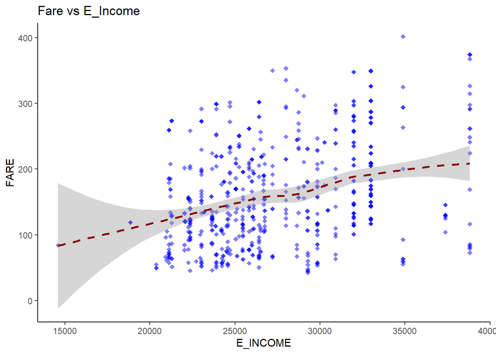

```r
ggplot(air.df, aes(x = E_INCOME, y = FARE)) +
  geom_point(size= 2, shape= 18, color = "blue", alpha = 0.5) +
  ggtitle("Fare vs E_Income")+
  geom_smooth(linetype="dashed",
             color="darkred")
```

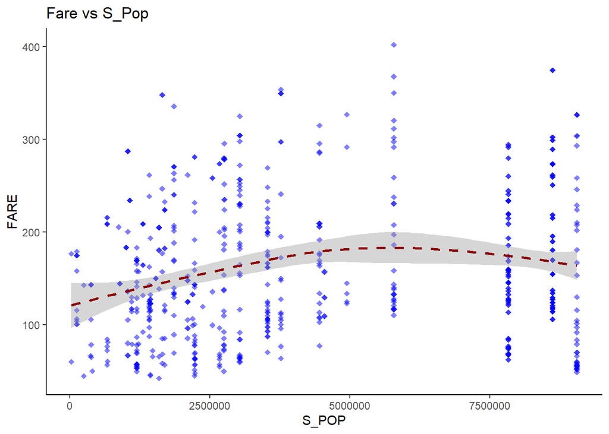

```r
ggplot(air.df, aes(x = S_POP, y = FARE)) +
  geom_point(size= 2, shape= 18, color = "blue", alpha = 0.5) +
  ggtitle("Fare vs S_Pop")+
  geom_smooth(linetype="dashed",
             color="darkred")
```

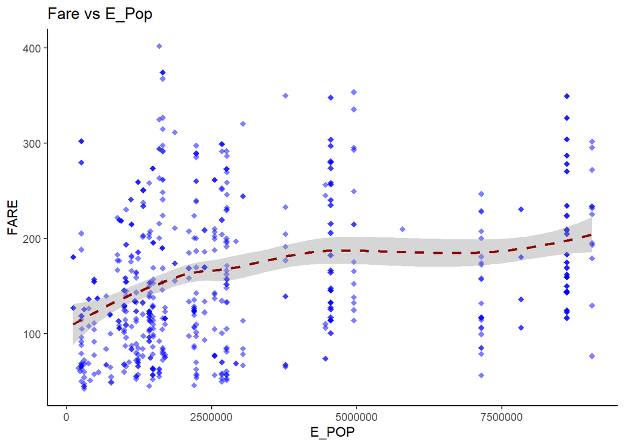

```r
ggplot(air.df, aes(x = E_POP, y = FARE)) +
  geom_point(size= 2, shape= 18, color = "blue", alpha = 0.5) +
  ggtitle("Fare vs E_Pop")+
  geom_smooth(linetype="dashed",
             color="darkred")
```

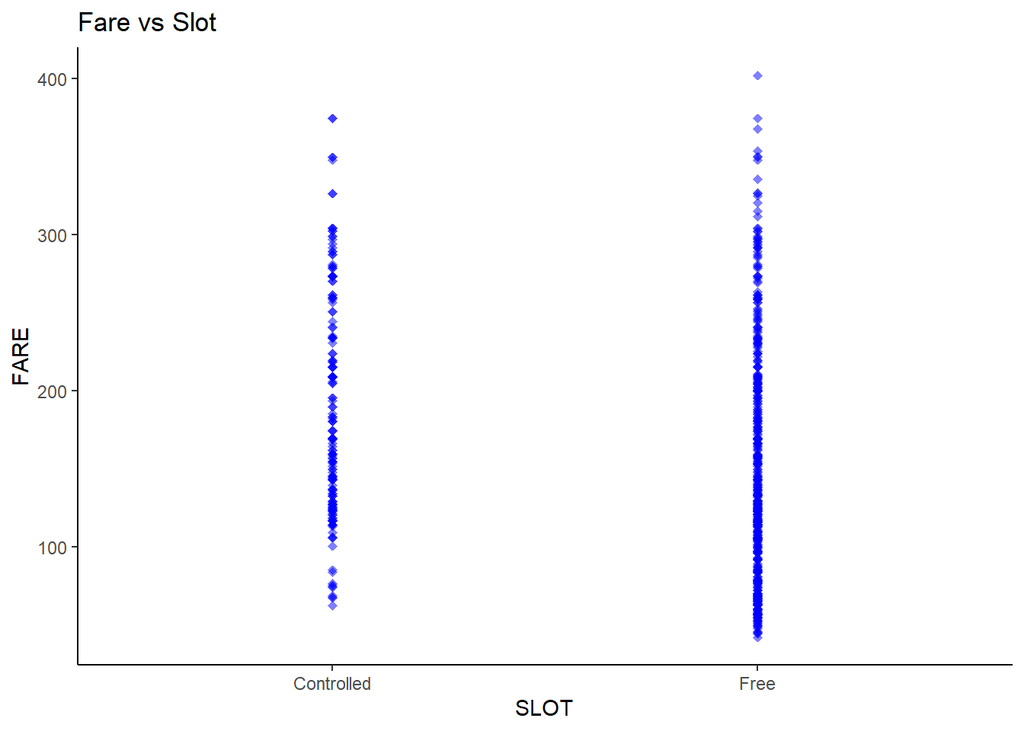

```r
ggplot(air.df, aes(x = SLOT, y = FARE)) +
  geom_point(size= 2, shape= 18, color = "blue", alpha = 0.5) +
  ggtitle("Fare vs Slot")+
  geom_smooth(linetype="dashed",
             color="darkred")
```

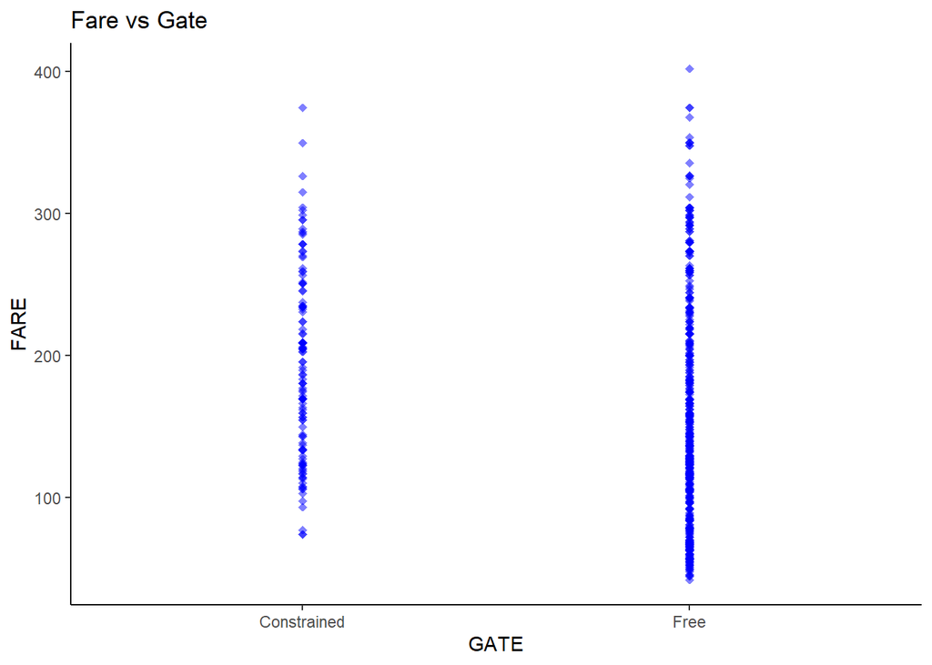

```r
ggplot(air.df, aes(x = GATE, y = FARE)) +
  geom_point(size= 2, shape= 18, color = "blue", alpha = 0.5) +
  ggtitle("Fare vs Gate")+
  geom_smooth(linetype="dashed",
             color="darkred")
```

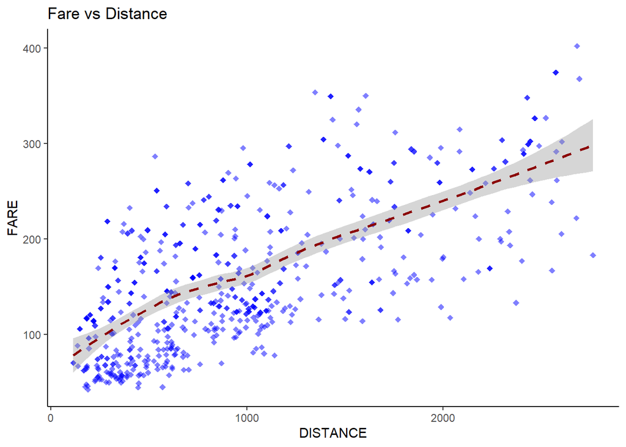

```r
ggplot(air.df, aes(x = DISTANCE, y = FARE)) +
  geom_point(size= 2, shape= 18, color = "blue", alpha = 0.5) +
  ggtitle("Fare vs Distance")+
  geom_smooth(linetype="dashed",
             color="darkred")
```

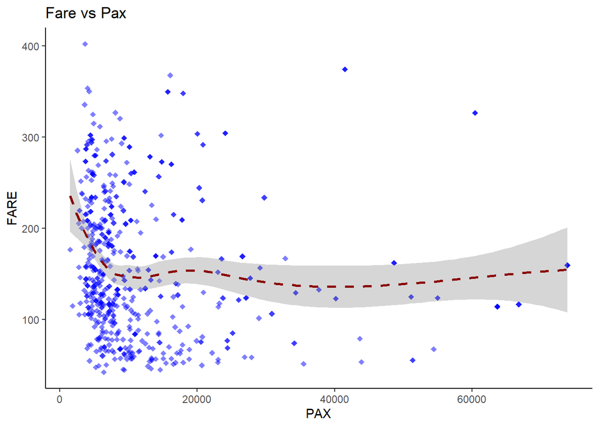

```r
ggplot(air.df, aes(x = PAX, y = FARE)) +
  geom_point(size= 2, shape= 18, color = "blue", alpha = 0.5) +
  ggtitle("Fare vs Pax")+
  geom_smooth(linetype="dashed",
             color="darkred")
```

**Question2** **Pivot tables for categorical predictors:**

```r
VACATION_f <- prop.table(table(air.df$VACATION))
SW_f <- prop.table(table(air.df$SW))
SLOT_f <- prop.table(table(air.df$SLOT))
GATE_f <- prop.table(table(air.df$GATE))

VACATION_AVG_Fare <- air.df %>% group_by(VACATION) %>% summarise(mean(FARE))
SW_AVG_Fare <- air.df %>% group_by(SW) %>% summarise(mean(FARE))
SLOT_AVG_Fare <- air.df %>% group_by(SLOT) %>% summarise(mean(FARE))
GATE_AVG_Fare <- air.df %>% group_by(GATE) %>% summarise(mean(FARE))

VACATION_PIVOT <- cbind(VACATION_f, VACATION_AVG_Fare)
VACATION_PIVOT['Freq'] <- VACATION_PIVOT['Freq']*100
VACATION_PIVOT$Var1<- NULL
VACATION_PIVOT <- VACATION_PIVOT[c("VACATION","Freq","mean(FARE)")]
names(VACATION_PIVOT)[2] <- "Percentage"
names(VACATION_PIVOT)[3] <- "AVERAGE FARE"
VACATION_PIVOT
```

```
##   VACATION Percentage AVERAGE FARE
## 1       No   73.35423     173.5525
## 2      Yes   26.64577     125.9809
```

```r
SW_PIVOT <- cbind(SW_f, SW_AVG_Fare)
SW_PIVOT['Freq'] <- SW_PIVOT['Freq']*100
SW_PIVOT$Var1<- NULL
SW_PIVOT <- SW_PIVOT[c("SW","Freq","mean(FARE)")]
names(SW_PIVOT)[2] <- "Percentage"
names(SW_PIVOT)[3] <- "AVERAGE FARE"
SW_PIVOT
```

```
##    SW Percentage AVERAGE FARE
## 1  No   69.59248    188.18279
## 2 Yes   30.40752     98.38227
```

```r
SLOT_PIVOT <- cbind(SLOT_f, SLOT_AVG_Fare)
SLOT_PIVOT['Freq'] <- SLOT_PIVOT['Freq']*100
SLOT_PIVOT$Var1<- NULL
SLOT_PIVOT <- SLOT_PIVOT[c("SLOT","Freq","mean(FARE)")]
names(SLOT_PIVOT)[2] <- "Percentage"
names(SLOT_PIVOT)[3] <- "AVERAGE FARE"
SLOT_PIVOT
```

```
##         SLOT Percentage AVERAGE FARE
## 1 Controlled   28.52665     186.0594
## 2       Free   71.47335     150.8257
```

```r
GATE_PIVOT <- cbind(GATE_f, GATE_AVG_Fare)
GATE_PIVOT['Freq'] <- GATE_PIVOT['Freq']*100
GATE_PIVOT$Var1<- NULL
GATE_PIVOT <- GATE_PIVOT[c("GATE","Freq","mean(FARE)")]
names(GATE_PIVOT)[2] <- "Percentage"
names(GATE_PIVOT)[3] <- "AVERAGE FARE"
GATE_PIVOT
```

```
##          GATE Percentage AVERAGE FARE
## 1 Constrained   19.43574      193.129
## 2        Free   80.56426      153.096
```

From the above pivot tables of categorical variables, we can see that the difference in the FARE with and without SW on the routes is highest with the percentage of 69.59% and 30.40% respectively and as compared to other categorical variables SW can impact the fare prices significantly. Hence, SW is the best predictor of FARE.

**Question3** **Data Partition:**

```r
set.seed(42)
rows <- sample(nrow(air.df))
air.df <- air.df[rows, ]

#rows to split on
split <- round(nrow(air.df) * (0.8))
train.df <- air.df[1:split, ]
test.df <- air.df[(split+1):nrow(air.df), ]
test.df
```

[output not shown]

[output cut: 243 more lines]

**Question4** **Stepwise Regression:**

```r
air.lm<- lm(FARE ~ ., data= train.df)
air.lm.stepwise <- step(air.lm,direction="both")
```

```
## Start:  AIC=3652.06
## FARE ~ COUPON + NEW + VACATION + SW + HI + S_INCOME + E_INCOME +
##     S_POP + E_POP + SLOT + GATE + DISTANCE + PAX
##
##            Df Sum of Sq     RSS    AIC
## - COUPON    1       911  622732 3650.8
## - NEW       1      1459  623280 3651.3
## - S_INCOME  1      1460  623281 3651.3
## <none>                   621821 3652.1
## - E_INCOME  1     17499  639320 3664.2
## - SLOT      1     17769  639590 3664.4
## - PAX       1     24441  646263 3669.7
## - E_POP     1     28296  650118 3672.8
## - GATE      1     28881  650702 3673.2
## - S_POP     1     36680  658501 3679.3
## - HI        1     76469  698290 3709.2
## - SW        1    105205  727026 3729.8
## - VACATION  1    113382  735204 3735.5
## - DISTANCE  1    417379 1039200 3912.0
##
## Step:  AIC=3650.81
## FARE ~ NEW + VACATION + SW + HI + S_INCOME + E_INCOME + S_POP +
##     E_POP + SLOT + GATE + DISTANCE + PAX
##
##            Df Sum of Sq     RSS    AIC
## - S_INCOME  1      1261  623994 3649.8
## - NEW       1      1678  624410 3650.2
## <none>                   622732 3650.8
## + COUPON    1       911  621821 3652.1
## - E_INCOME  1     17126  639859 3662.6
## - SLOT      1     18407  641139 3663.7
## - GATE      1     29285  652018 3672.2
## - E_POP     1     29484  652217 3672.4
## - PAX       1     34128  656860 3676.0
## - S_POP     1     36089  658821 3677.5
## - HI        1     78594  701326 3709.4
## - SW        1    107735  730468 3730.2
## - VACATION  1    114276  737009 3734.7
## - DISTANCE  1    824468 1447200 4078.9
##
```

[output cut: 24 more lines]

```
##            Df Sum of Sq     RSS    AIC
## <none>                   625690 3649.2
## + NEW       1      1697  623994 3649.8
## + S_INCOME  1      1280  624410 3650.2
## + COUPON    1       907  624783 3650.5
## - E_INCOME  1     15649  641339 3659.8
## - SLOT      1     19217  644907 3662.6
## - E_POP     1     28766  654456 3670.1
## - GATE      1     29165  654856 3670.5
## - PAX       1     32706  658396 3673.2
## - S_POP     1     42648  668338 3680.9
## - HI        1     78891  704581 3707.8
## - SW        1    126577  752267 3741.2
## - VACATION  1    127066  752756 3741.5
## - DISTANCE  1    825966 1451656 4076.4
```

```r
summary(air.lm.stepwise)
```

```
##
## Call:
## lm(formula = FARE ~ VACATION + SW + HI + E_INCOME + S_POP + E_POP +
##     SLOT + GATE + DISTANCE + PAX, data = train.df)
##
## Residuals:
##     Min      1Q  Median      3Q     Max
## -99.148 -22.077  -2.028  21.491 107.744
##
## Coefficients:
##               Estimate Std. Error t value Pr(>|t|)
## (Intercept)  4.208e+01  1.476e+01   2.851 0.004534 **
## VACATIONYes -3.876e+01  3.850e+00 -10.067  < 2e-16 ***
## SWYes       -4.053e+01  4.034e+00 -10.047  < 2e-16 ***
## HI           8.268e-03  1.042e-03   7.932 1.43e-14 ***
## E_INCOME     1.445e-03  4.089e-04   3.533 0.000450 ***
## S_POP        4.185e-06  7.176e-07   5.832 9.85e-09 ***
## E_POP        3.779e-06  7.890e-07   4.790 2.21e-06 ***
## SLOTFree    -1.685e+01  4.305e+00  -3.915 0.000103 ***
## GATEFree    -2.122e+01  4.399e+00  -4.823 1.88e-06 ***
## DISTANCE     7.367e-02  2.870e-03  25.666  < 2e-16 ***
## PAX         -7.619e-04  1.492e-04  -5.107 4.66e-07 ***
## ---
## Signif. codes:  0 '***' 0.001 '**' 0.01 '*' 0.05 '.' 0.1 ' ' 1
##
## Residual standard error: 35.41 on 499 degrees of freedom
## Multiple R-squared:  0.7803, Adjusted R-squared:  0.7759
## F-statistic: 177.2 on 10 and 499 DF,  p-value: < 2.2e-16
```

```r
air.lm.stepwise.pred<-  predict(air.lm.stepwise, test.df)
```

The model above has dropped three variables based on the decreasing AIC values which are COUPON, S_INCOME, and NEW respectively which finalizes the minimum AIC value to 3649.22. The p value is much less than 0.05 and the adjusted R square value is 0.7759 which states that this model can explain 77.59% of changes in the FARE.

**Question5** **Exhaustive Search:**

```r
search <- regsubsets(FARE ~ ., data = train.df, nbest = 1, nvmax = dim(train.df)[2],
                     method = "exhaustive")
sum <- summary(search)
sum$which
```

```
##    (Intercept) COUPON   NEW VACATIONYes SWYes    HI S_INCOME E_INCOME S_POP
## 1         TRUE  FALSE FALSE       FALSE FALSE FALSE    FALSE    FALSE FALSE
## 2         TRUE  FALSE FALSE       FALSE  TRUE FALSE    FALSE    FALSE FALSE
## 3         TRUE  FALSE FALSE        TRUE  TRUE FALSE    FALSE    FALSE FALSE
## 4         TRUE  FALSE FALSE        TRUE  TRUE  TRUE    FALSE    FALSE FALSE
## 5         TRUE  FALSE FALSE        TRUE  TRUE  TRUE    FALSE    FALSE FALSE
## 6         TRUE  FALSE FALSE        TRUE  TRUE  TRUE    FALSE    FALSE FALSE
## 7         TRUE  FALSE FALSE        TRUE  TRUE  TRUE    FALSE    FALSE  TRUE
## 8         TRUE  FALSE FALSE        TRUE  TRUE  TRUE    FALSE     TRUE  TRUE
## 9         TRUE  FALSE FALSE        TRUE  TRUE  TRUE    FALSE    FALSE  TRUE
## 10        TRUE  FALSE FALSE        TRUE  TRUE  TRUE    FALSE     TRUE  TRUE
## 11        TRUE  FALSE  TRUE        TRUE  TRUE  TRUE    FALSE     TRUE  TRUE
## 12        TRUE  FALSE  TRUE        TRUE  TRUE  TRUE     TRUE     TRUE  TRUE
## 13        TRUE   TRUE  TRUE        TRUE  TRUE  TRUE     TRUE     TRUE  TRUE
##    E_POP SLOTFree GATEFree DISTANCE   PAX
## 1  FALSE    FALSE    FALSE     TRUE FALSE
## 2  FALSE    FALSE    FALSE     TRUE FALSE
## 3  FALSE    FALSE    FALSE     TRUE FALSE
## 4  FALSE    FALSE    FALSE     TRUE FALSE
## 5  FALSE     TRUE    FALSE     TRUE FALSE
## 6  FALSE     TRUE     TRUE     TRUE FALSE
## 7   TRUE    FALSE    FALSE     TRUE  TRUE
## 8   TRUE    FALSE    FALSE     TRUE  TRUE
## 9   TRUE     TRUE     TRUE     TRUE  TRUE
## 10  TRUE     TRUE     TRUE     TRUE  TRUE
## 11  TRUE     TRUE     TRUE     TRUE  TRUE
## 12  TRUE     TRUE     TRUE     TRUE  TRUE
## 13  TRUE     TRUE     TRUE     TRUE  TRUE
```

```r
sum$rsq
```

```
##  [1] 0.4168069 0.5793894 0.6966218 0.7232479 0.7366555 0.7565835 0.7607777
##  [8] 0.7674947 0.7748171 0.7803115 0.7809073 0.7813501 0.7816700
```

```r
sum$adjr2
```

```
##  [1] 0.4156589 0.5777302 0.6948231 0.7210558 0.7340429 0.7536799 0.7574419
##  [8] 0.7637820 0.7707638 0.7759090 0.7760679 0.7760708 0.7759476
```

```r
sum$cp
```

```
##  [1] 818.89220 451.53899 187.21153 128.72255 100.26346  56.99127  49.46286
##  [8]  36.20326  21.56831  11.08605  11.73270  12.72670  14.00000
```

From the above Exhaustive search, we need to select the set of variables having highest adjusted R square value. The highest adjusted R square value in the above model is 0.77607 which is the 12th row and has 12 variables. But, for accuracy we will consider the CP values as the values look close to each other. From CP value results, we can see that cp<= p+1 is satisfies by 11th row and so we consider all the variables except COUPON and S_INCOME. By comparing Exhaustive search model with the stepwise regression model we see that adjusted R squared value in stepwise model was 0.7759 whereas in exhaustive model is 0.77607. Also the stepwise model dropped three variables whereas the exhaustive model dropped two variables.

**Question6** **Comparing Predictive Accuracy:**

```r
accuracy(air.lm.stepwise.pred, test.df$FARE) # Stepwise Accuracy
```

```
##               ME    RMSE      MAE       MPE     MAPE
## Test set 3.06081 36.8617 27.70568 -5.938062 21.62142
```

```r
air.exhaustive.lm <- lm(FARE~ COUPON+NEW+VACATION+SW+HI+E_INCOME+S_POP+E_POP+SLOT+GATE+
                       DISTANCE+PAX, data = train.df )
predict.exhaustive.lm <- predict(air.exhaustive.lm, test.df)
accuracy(predict.exhaustive.lm, test.df$FARE) # Exhaustive Accuracy
```

```
##                ME     RMSE      MAE       MPE     MAPE
## Test set 3.065742 36.97323 27.59975 -5.852725 21.47488
```

**Question7** **Predict Average Fare on a route:**

```r
test2.df <- data.frame(COUPON = 1.202, NEW = 3, VACATION = 'No', SW = 'No',
                       HI = 4442.141, S_INCOME = 28760, E_INCOME = 27664, S_POP = 4557004,
                       E_POP = 3195503, SLOT = 'Free', GATE = 'Free',
                       PAX = 12782, DISTANCE = 1976)
predict.exhaustive.lm2 <- predict(air.exhaustive.lm, test2.df)
predict.exhaustive.lm2
```

```
##        1
## 245.2815
```

From the above results of exhaustive search model, the average fare on a route with given characteristics is $245.2815.

**Question8** **Predict Reduction in average fare:**

```r
test3.df <- data.frame(COUPON = 1.202, NEW = 3, VACATION = 'No',
                       SW = 'Yes', HI = 4442.141, S_INCOME = 28760,
                       E_INCOME = 27664, S_POP = 4557004, E_POP = 3195503,
                       SLOT = 'Free', GATE = 'Free', PAX = 12782, DISTANCE = 1976)
predict.exhaustive.lm3 <- predict(air.exhaustive.lm, test3.df)
predict.exhaustive.lm3
```

```
##        1
## 204.8958
```

```r
predict.exhaustive.lm2-predict.exhaustive.lm3
```

```
##        1
## 40.38569
```

If southwest decides to cover the route, using the exhaustive search model, the average fare turns out to be $204.8958 with a reduction of $40.38569.

**Question9** **Backward Selection Regression:**

```r
air.lm.bselect <- step(air.lm, direction = "backward")
```

```
## Start:  AIC=3652.06
## FARE ~ COUPON + NEW + VACATION + SW + HI + S_INCOME + E_INCOME +
##     S_POP + E_POP + SLOT + GATE + DISTANCE + PAX
##
##            Df Sum of Sq     RSS    AIC
## - COUPON    1       911  622732 3650.8
## - NEW       1      1459  623280 3651.3
## - S_INCOME  1      1460  623281 3651.3
## <none>                   621821 3652.1
## - E_INCOME  1     17499  639320 3664.2
## - SLOT      1     17769  639590 3664.4
## - PAX       1     24441  646263 3669.7
## - E_POP     1     28296  650118 3672.8
## - GATE      1     28881  650702 3673.2
## - S_POP     1     36680  658501 3679.3
## - HI        1     76469  698290 3709.2
## - SW        1    105205  727026 3729.8
## - VACATION  1    113382  735204 3735.5
## - DISTANCE  1    417379 1039200 3912.0
##
## Step:  AIC=3650.81
## FARE ~ NEW + VACATION + SW + HI + S_INCOME + E_INCOME + S_POP +
##     E_POP + SLOT + GATE + DISTANCE + PAX
##
##            Df Sum of Sq     RSS    AIC
## - S_INCOME  1      1261  623994 3649.8
## - NEW       1      1678  624410 3650.2
## <none>                   622732 3650.8
## - E_INCOME  1     17126  639859 3662.6
## - SLOT      1     18407  641139 3663.7
## - GATE      1     29285  652018 3672.2
## - E_POP     1     29484  652217 3672.4
## - PAX       1     34128  656860 3676.0
## - S_POP     1     36089  658821 3677.5
## - HI        1     78594  701326 3709.4
## - SW        1    107735  730468 3730.2
## - VACATION  1    114276  737009 3734.7
## - DISTANCE  1    824468 1447200 4078.9
##
## Step:  AIC=3649.84
```

[output cut: 18 more lines]

```
## FARE ~ VACATION + SW + HI + E_INCOME + S_POP + E_POP + SLOT +
##     GATE + DISTANCE + PAX
##
##            Df Sum of Sq     RSS    AIC
## <none>                   625690 3649.2
## - E_INCOME  1     15649  641339 3659.8
## - SLOT      1     19217  644907 3662.6
## - E_POP     1     28766  654456 3670.1
## - GATE      1     29165  654856 3670.5
## - PAX       1     32706  658396 3673.2
## - S_POP     1     42648  668338 3680.9
## - HI        1     78891  704581 3707.8
## - SW        1    126577  752267 3741.2
## - VACATION  1    127066  752756 3741.5
## - DISTANCE  1    825966 1451656 4076.4
```

```r
summary(air.lm.bselect)
```

```
##
## Call:
## lm(formula = FARE ~ VACATION + SW + HI + E_INCOME + S_POP + E_POP +
##     SLOT + GATE + DISTANCE + PAX, data = train.df)
##
## Residuals:
##     Min      1Q  Median      3Q     Max
## -99.148 -22.077  -2.028  21.491 107.744
##
## Coefficients:
##               Estimate Std. Error t value Pr(>|t|)
## (Intercept)  4.208e+01  1.476e+01   2.851 0.004534 **
## VACATIONYes -3.876e+01  3.850e+00 -10.067  < 2e-16 ***
## SWYes       -4.053e+01  4.034e+00 -10.047  < 2e-16 ***
## HI           8.268e-03  1.042e-03   7.932 1.43e-14 ***
## E_INCOME     1.445e-03  4.089e-04   3.533 0.000450 ***
## S_POP        4.185e-06  7.176e-07   5.832 9.85e-09 ***
## E_POP        3.779e-06  7.890e-07   4.790 2.21e-06 ***
## SLOTFree    -1.685e+01  4.305e+00  -3.915 0.000103 ***
## GATEFree    -2.122e+01  4.399e+00  -4.823 1.88e-06 ***
## DISTANCE     7.367e-02  2.870e-03  25.666  < 2e-16 ***
## PAX         -7.619e-04  1.492e-04  -5.107 4.66e-07 ***
## ---
## Signif. codes:  0 '***' 0.001 '**' 0.01 '*' 0.05 '.' 0.1 ' ' 1
##
## Residual standard error: 35.41 on 499 degrees of freedom
## Multiple R-squared:  0.7803, Adjusted R-squared:  0.7759
## F-statistic: 177.2 on 10 and 499 DF,  p-value: < 2.2e-16
```

```r
air.lm.bselect.pred <- predict(air.lm.bselect, test.df)
accuracy(air.lm.bselect.pred, test.df$FARE)
```

```
##               ME    RMSE      MAE       MPE     MAPE
## Test set 3.06081 36.8617 27.70568 -5.938062 21.62142
```

As we can see in the above results, the backward selection model dropped three variable, COUPON, S_INCOME, and NEW. The RMSE value using backward selection model is 36.8617 which is same as that of stepwise regression because both the models dropprd same set of variables. Although the RMSE value of backward selection model is less than that of the exhaustive search model.

**Question10** **Backward Selection model using stepAIC():**

```r
air.lm.step2 <- stepAIC(air.lm, direction = "backward")
```

```
## Start:  AIC=3652.06
## FARE ~ COUPON + NEW + VACATION + SW + HI + S_INCOME + E_INCOME +
##     S_POP + E_POP + SLOT + GATE + DISTANCE + PAX
##
##            Df Sum of Sq     RSS    AIC
## - COUPON    1       911  622732 3650.8
## - NEW       1      1459  623280 3651.3
## - S_INCOME  1      1460  623281 3651.3
## <none>                   621821 3652.1
## - E_INCOME  1     17499  639320 3664.2
## - SLOT      1     17769  639590 3664.4
## - PAX       1     24441  646263 3669.7
## - E_POP     1     28296  650118 3672.8
## - GATE      1     28881  650702 3673.2
## - S_POP     1     36680  658501 3679.3
## - HI        1     76469  698290 3709.2
## - SW        1    105205  727026 3729.8
## - VACATION  1    113382  735204 3735.5
## - DISTANCE  1    417379 1039200 3912.0
##
## Step:  AIC=3650.81
## FARE ~ NEW + VACATION + SW + HI + S_INCOME + E_INCOME + S_POP +
##     E_POP + SLOT + GATE + DISTANCE + PAX
##
##            Df Sum of Sq     RSS    AIC
## - S_INCOME  1      1261  623994 3649.8
## - NEW       1      1678  624410 3650.2
## <none>                   622732 3650.8
## - E_INCOME  1     17126  639859 3662.6
## - SLOT      1     18407  641139 3663.7
## - GATE      1     29285  652018 3672.2
## - E_POP     1     29484  652217 3672.4
## - PAX       1     34128  656860 3676.0
## - S_POP     1     36089  658821 3677.5
## - HI        1     78594  701326 3709.4
## - SW        1    107735  730468 3730.2
## - VACATION  1    114276  737009 3734.7
## - DISTANCE  1    824468 1447200 4078.9
##
## Step:  AIC=3649.84
```

[output cut: 18 more lines]

```
## FARE ~ VACATION + SW + HI + E_INCOME + S_POP + E_POP + SLOT +
##     GATE + DISTANCE + PAX
##
##            Df Sum of Sq     RSS    AIC
## <none>                   625690 3649.2
## - E_INCOME  1     15649  641339 3659.8
## - SLOT      1     19217  644907 3662.6
## - E_POP     1     28766  654456 3670.1
## - GATE      1     29165  654856 3670.5
## - PAX       1     32706  658396 3673.2
## - S_POP     1     42648  668338 3680.9
## - HI        1     78891  704581 3707.8
## - SW        1    126577  752267 3741.2
## - VACATION  1    127066  752756 3741.5
## - DISTANCE  1    825966 1451656 4076.4
```

```r
summary(air.lm.step2)
```

```
##
## Call:
## lm(formula = FARE ~ VACATION + SW + HI + E_INCOME + S_POP + E_POP +
##     SLOT + GATE + DISTANCE + PAX, data = train.df)
##
## Residuals:
##     Min      1Q  Median      3Q     Max
## -99.148 -22.077  -2.028  21.491 107.744
##
## Coefficients:
##               Estimate Std. Error t value Pr(>|t|)
## (Intercept)  4.208e+01  1.476e+01   2.851 0.004534 **
## VACATIONYes -3.876e+01  3.850e+00 -10.067  < 2e-16 ***
## SWYes       -4.053e+01  4.034e+00 -10.047  < 2e-16 ***
## HI           8.268e-03  1.042e-03   7.932 1.43e-14 ***
## E_INCOME     1.445e-03  4.089e-04   3.533 0.000450 ***
## S_POP        4.185e-06  7.176e-07   5.832 9.85e-09 ***
## E_POP        3.779e-06  7.890e-07   4.790 2.21e-06 ***
## SLOTFree    -1.685e+01  4.305e+00  -3.915 0.000103 ***
## GATEFree    -2.122e+01  4.399e+00  -4.823 1.88e-06 ***
## DISTANCE     7.367e-02  2.870e-03  25.666  < 2e-16 ***
## PAX         -7.619e-04  1.492e-04  -5.107 4.66e-07 ***
## ---
## Signif. codes:  0 '***' 0.001 '**' 0.01 '*' 0.05 '.' 0.1 ' ' 1
##
## Residual standard error: 35.41 on 499 degrees of freedom
## Multiple R-squared:  0.7803, Adjusted R-squared:  0.7759
## F-statistic: 177.2 on 10 and 499 DF,  p-value: < 2.2e-16
```

```r
air.lm.step2.pred <- predict(air.lm.step2, test.df)
accuracy(air.lm.step2.pred, test.df$FARE)
```

```
##               ME    RMSE      MAE       MPE     MAPE
## Test set 3.06081 36.8617 27.70568 -5.938062 21.62142
```

The AIC value decreases as we drop each variable till we get the best-fit model. The AIC values in the Backward and StepAIC methods are same as 3649.22 (minimum). The values came out to be same because both the models have dropped the same set of variables which are COUPON, NEW, and S_Income. Hence, we did not see any effect of using StepAIC function in this case.